# Clustering

## Introduction

In this task, individuals heard spoken speech tokens and freely classified them into groups. Using hierarchical clustering we aimed to see what clusters or groups appear as a result of the free classification task.

45 speech samples were selected from The Speech Accent Archive. The talkers included three American English regional dialects, three international English dialects, and nine nonnative accents. The nonnative accents were split into three accents from East Asia, three accents from South Asia, and three accents from Southeast Asia. The American English dialects included the New England dialect, the Southern dialect, and the Midland dialect. The international English dialects included British English, Australian English, and Africaans. The native languages of the nonnative-accented talkers were Mandarin, Korean, and Japanese from East Asia, Bengali, Gujarati, and Urdu from South Asia, and Indonesian, Tagalog, and Thai from Southeast Asia.

```r
# For reproducibility
set.seed(666)
```

```r
library(here)
library(tidyverse)  # data manipulation
library(cluster)    # clustering algorithms
library(factoextra) # clustering visualization
```

```r
library(dendextend) # for comparing two dendrograms
```

### Data Preparation

1. Rows are observations (individuals) and columns are variables
2. Any missing value in the data must be removed or estimated.
3. The data must be standardized (i.e., scaled) to make variables comparable (I am not doing this here).

### Read in the data

```r
clust_data <- read_csv(here("data", "class_wide_1.csv")) # read in data
clust_data <- select(clust_data, -X1, -`54`) # remove extra col sub 54 has weird formatting

clust_data <- as.data.frame(clust_data) # turn into df

rownames(clust_data) <- clust_data$speaker # make row names speaker

clust_data <- select(clust_data,-speaker) # remove extra col sub 54 has weird formatting

head(clust_data)# show first couple rows
```

```
##             8 7 1 10 11 12 14 15 16 17 18 19 2 20 23 25 26 27 28 29  3 30 31 32
## bengali_9   1 5 5  1 11  2  1  8  4  2  2  1 9  7  4  5  1  1  1 11  5  1  7  7
## bengali_13  6 5 5  7 14  4  2  7  4  2  6  3 9  1  4  5  4  2  3 11 12  1  8 11
## bengali_16  1 5 5  7  7  4  3  6  2  8  3  3 3  1  3  4  6  1  3 10  2  1  7  8
## gujarati_5  4 5 5  1 14  4  1  7  4  9  9  1 9  4  3  5  4  2  4  8  9  1  7  9
## gujarati_13 1 5 5  1 15  4  2  8  4  2  6  1 9  4  5  5  6  2  4  8  5  1  7  9
## gujarati_14 5 5 5  1  7  4  1  8  4  9  9  3 9  5  7  5  4  4  6  1  5  1  6  9
##             33 34 35 36 38 4 40 41 42 43 44 45 46 47 48 49  5 50 51 52 53 55 56
## bengali_9    9  8 10  8  1 3  1 10  1  1 12  1  5  1  5  8  1  3  7  1  8  9  1
## bengali_13   9  8 10 11  1 4 12  1  1  8 11  1  5  4  1  8  5  4  7  3  8  9  1
## bengali_16   9  8 10 11  6 3  8  8  1  8 11  1  1  2  5  7  5  4  7  3  8  9  8
## gujarati_5   9  6 10  8  1 2  8  7  1  8  8  3 11  2  2  8 10  3  7 11  8  9  7
## gujarati_13  9  8 10  2  1 2 12  1  1  8 11  1 11  6  5  8  2  4  7  1  8  9  7
## gujarati_14  9  6 10  9  1 4 13  2  1  8 11  6  3  4  5  8  3  3  7 15  8  8  8
##             58 59 6 78 87 90 91 96 105 110 111 115 121 123 125 132 133 135 148
## bengali_9    1  5 9  1 11  1 11  1   6  11   1   2   1   9   1   3   1   1   1
## bengali_13   8 11 7  1 11  1 11  1   6  11   7   8   6   9   1   6   2   3   6
## bengali_16   1  6 7  5 11  2  6  1   6  10   6   8   6  10  10   4   2   3   1
## gujarati_5   3 11 7  1 11  2 10  1   1  11   6   8   6   9  10   4   3   2   3
## gujarati_13 10  5 7  1 11  2 11  1   6  11   2   8   6   9  10   4   2   1   1
## gujarati_14  6  5 6  2 11  8 11  1   6  11   6   9   6   9   8   4   2   1   2
##             151 152 153 155 156 157 158 159 160 161 162 163 164 165 166 167 168
## bengali_9     5   1   8   4   8   6   5   1   5   1   7   4   1   5   1   7   1
## bengali_13    9   1   8   4  10   6   5   2   1  14   7   6   4   5   1   4   2
## bengali_16    7   4   8  11   8   6   3   2   3  14   7   7   1   5   1   7   4
## gujarati_5    5   3   2   5   9   6   3   1   3  14   7   5   6   6   1   4   2
## gujarati_13   5   1   2   5   9   6   3   1   4  14   7   5   6   5   1   7   3
## gujarati_14   5   3   8   5   9   6   3   8   4   5   3   7   6   7   6   7   5
##             169
## bengali_9     2
## bengali_13    4
## bengali_16    4
## gujarati_5    5
## gujarati_13   6
## gujarati_14   1
```

## Agglomerative Hierarchical Clustering

I am going to cluster the data using average link clustering. Average link clustering computes all pairwise dissimilarities between the elements, and considers the average of these dissimilarities as the distance between clusters.

First, we calculate the dissimilarity matrix using euclidean distance.

Second, we comput the clustering with average link.

Third, we plot the cluster solution

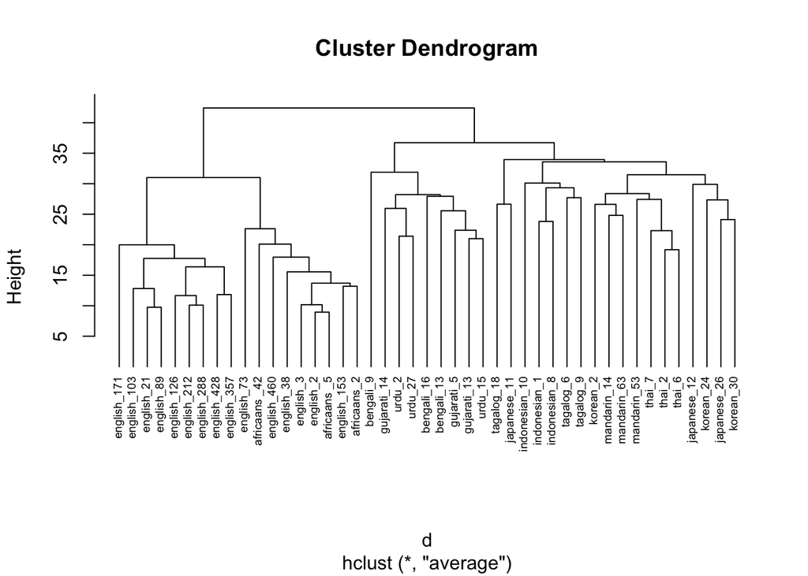

```r
# Dissimilarity matrix
d <- dist(clust_data, method = "euclidean")

# Hierarchical clustering using Average Linkage
hc1 <- hclust(d, method = "average" )

# Plot the obtained dendrogram
plot(hc1, cex = 0.6, hang = -1)
```

In the dendrogram displayed above, each leaf corresponds to one observation. As we move up the tree, observations that are similar to each other are combined into branches, which are themselves fused at a higher height.

The height of the fusion, provided on the vertical axis, indicates the (dis)similarity between two observations. The higher the height of the fusion, the less similar the observations are. Note that, conclusions about the proximity of two observations can be drawn only based on the height where branches containing those two observations first are fused. We cannot use the proximity of two observations along the horizontal axis as a criteria of their similarity.

The height of the cut to the dendrogram controls the number of clusters obtained. It plays the same role as the k in k-means clustering. In order to identify sub-groups (i.e. clusters), we can cut the dendrogram with cutree

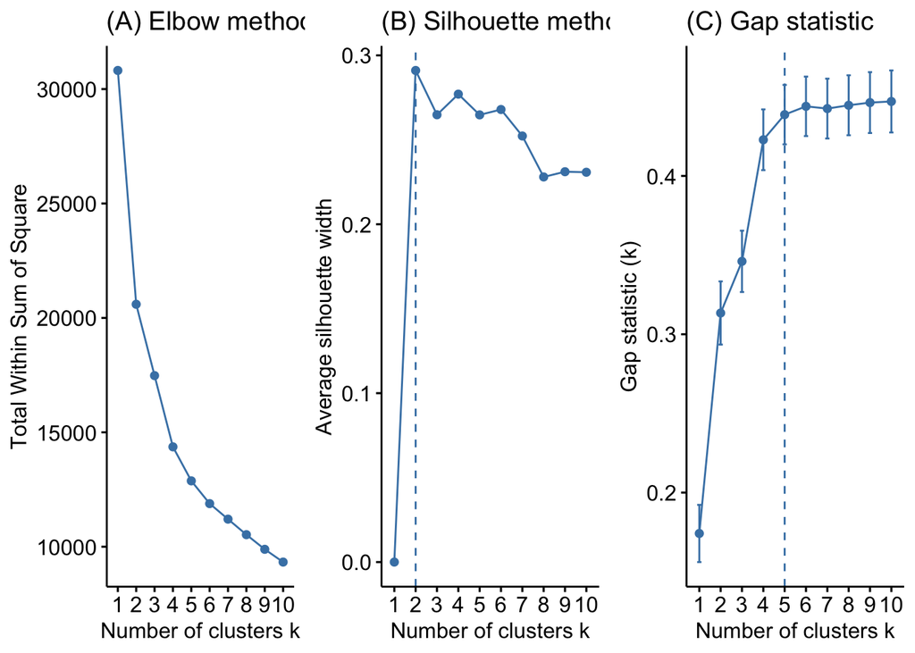

```r
# Plot cluster results
p1 <- fviz_nbclust(clust_data, FUN = hcut, method = "wss",
                   k.max = 10) +
  ggtitle("(A) Elbow method")
p2 <- fviz_nbclust(clust_data, FUN = hcut, method = "silhouette",
                   k.max = 10) +
  ggtitle("(B) Silhouette method")
p3 <- fviz_nbclust(clust_data, FUN = hcut, method = "gap_stat",
                   k.max = 10) +
  ggtitle("(C) Gap statistic")

# Display plots side by side
gridExtra::grid.arrange(p1, p2, p3, nrow = 1)
```

### Dendrogram

Although it is a bit ambiguous I would say 3 clusters are the most interpreatable. I could be wrong.

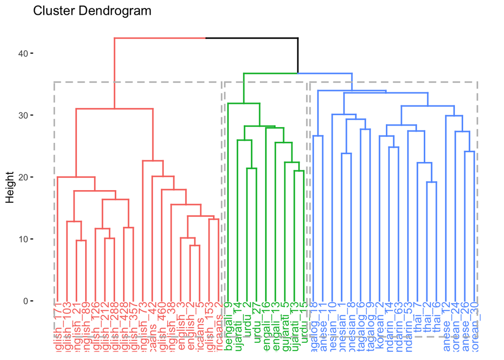

```r
hc.cut <- hcut(clust_data, k = 3, hc_method = "average")

fviz_dend(hc.cut, show_labels = TRUE, rect = TRUE)
```

### Visualize Clusters

#### 3 Clusters

```r
# Cut tree into 3 groups
sub_grp <- cutree(hc.cut, k = 3)

# Number of members in each cluster
table(sub_grp)
```

```
## sub_grp
##  1  2  3
##  9 18 18
```

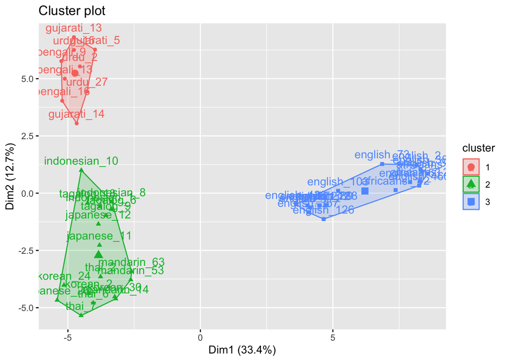

```r
fviz_cluster(list(data = clust_data, cluster = sub_grp))
```

#### 4 clusters

```r
# Cut tree into 3 groups
sub_grp <- cutree(hc.cut, k = 4)

# Number of members in each cluster
table(sub_grp)
```

```
## sub_grp
##  1  2  3  4
##  9 16  2 18
```

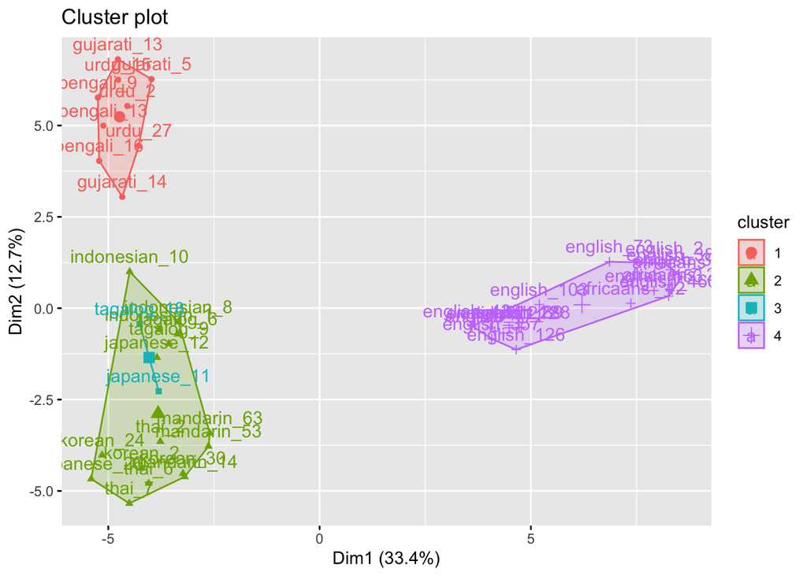

```r
fviz_cluster(list(data = clust_data, cluster = sub_grp))
```

#### 5 clusters

```r
# Cut tree into 3 groups
sub_grp <- cutree(hc.cut, k = 5)

# Number of members in each cluster
table(sub_grp)
```

```
## sub_grp
##  1  2  3  4  5
##  9  5  2 11 18
```

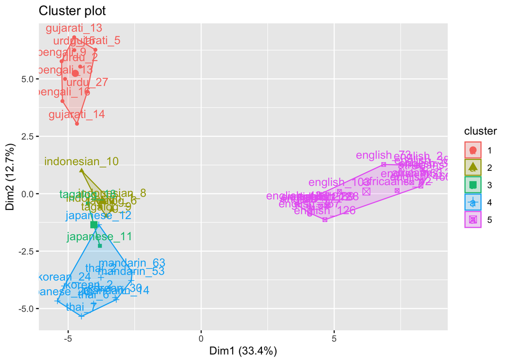

```r
fviz_cluster(list(data = clust_data, cluster = sub_grp))
```

# Conclusion

I ran a hierarchical clustering analysis using the average link method to classify talkers in a free classification task. I made the decision that 3 clusters looks good. This is a subjective decision. You might think that 4 or 5 clusters makes more sense. You should refer to the elbow, shilotte, and gap plots above.